# 統計計算與模擬 Homework02

105354003林芃彣 ＆ 105354030陳媚

Mar, 27, 2017

## 第一題

1. Write a computer program using the Mid-Square 3/7 Method using 6 digits to generate 10,000 random numbers ranging over [0, 999999]. Use the Kolmogorov-Smirnov Goodness-of-fit test to see if the random numbers that you create are uniformly distributed. (Note: You must notify the initial seed number used, and you may adapt 0.05 as the value. Also, you may find warning messages for conducting the Goodness-of-fit test, and comment on the Goodness-of-fit test. )
2. Consider the random number generator $X_{i+1} = 69069X_i (mod2^{32})$ , i.e., the generator used by Vax before 1993. Use both the $\chi^2$ and Kolmogorov-Smirnov Goodness-of-fit tests to check if the data are from U(0,1) distribution. Compare the result with those in (a) & (b), and discuss your finding based on the comparison.
3. In class, we often use simulation tools in R, such as “sample” or “ceiling(runif),” to generate random numbers from 1 to k, where k is a natural number. Using graphical tools (such as histogram) and statistical tests to check which one is a better tool in producing uniform numbers between 1 and k. (Hint: You may check if the size of k matters by, for example, assigning k a small and big value.)
- (a)：the Mid-SquareMethod :隨機選取一個 m 位數的種子，平方後，得到的數不足 2m 在前面補 0 ，取中間的m個數作為新的數
- 作法：先隨機生成一個6位數的 seed，平方後得到數無論是否需要補0，新的數都是從千位數起往前取 6 個數，所以先取 $10^9$位數(通過取餘數的方法)，再減去千位數，再除以 1000 得到新的數，由 ks.test 的檢定顯示這個方式取到的亂數有重複值， pvalue 很小說明顯著，平方取中法得到的亂數不是一個 uniform 分佈，用 jitter 給重複值加躁，這個方法不会影響數據分布，也不会影響最终的檢測结果。

```r
c <- 100000:999999
seed = sample(c,1)
seed
```

```
## [1] 497599
```

```r
x = seed
m = NULL
for (i in 1:10000){
  a = (x^2) %% 1000000000
  x = (a-(a%%1000))/1000
  m <- c(m , x)
}

ks.test(jitter(m),"punif",1,999999)
```

```
##
##  One-sample Kolmogorov-Smirnov test
##
## data:  jitter(m)
## D = 0.052588, p-value < 2.2e-16
## alternative hypothesis: two-sided
```

```r
seed = sample(c(1:1000),1)
x = seed
m = NULL
for (i in 1:10000){
  a = x*69069
  x = a%%(2^32)
  m <- c(m,x)
}
ks.test(m/max(m),"punif")
```

```
##
##  One-sample Kolmogorov-Smirnov test
##
## data:  m/max(m)
## D = 0.0069639, p-value = 0.7172
## alternative hypothesis: two-sided
```

```r
y1 = matrix(m/max(m),nrow=4,byrow=F)   #卡方檢定
y2 = apply(y1,2,rank)
y3 = y2[1,]*1000 + y2[2,]*100 + y2[3,]*10 + y2[4,]
a1 = table(y3)
#方法二：chisq.test(a1)
c = 2500/24
p = sum((a1-c)^2/c)
1-pchisq(p,23)
```

```
## [1] 0.03212672
```

- (c)：想要看用 sample 和 ceiling 兩種方法生成在 (1：k) 中的 N 個亂數，用圖像和統計檢定查看哪種方法更優，考慮影響亂數生成的因素有 k ，所以分別取 k=100,10000，N=1000。
- 圖像觀察法：k=100 時，無法區分確定哪個方法得到的亂數更接近 uniform 分佈；k=10000 時，ceiling 方法取得的亂數更接近 uniform 分佈。
- ks.test : 用這 4 種組合個產生 1000 組做檢定，在 $\alpha=0.05$ 下，拒絕的次數如下方表格所示， ceiling 拒絕的次數稍微比 sample 多了一點點，可以說差距很微小。

```r
A = NULL
t1 <- function(x){ifelse (ks.test(jitter(x),"punif",1,100)$p.value<0.05,1,0)}
t2 <- function(x){ifelse (ks.test(jitter(x),"punif",1,10000)$p.value<0.05,1,0)}
for (i in 1:1000){
y1 = sample(1:100,1000,replace=TRUE)
y2 = ceiling(runif(1000,1,100))
y3 = sample(1:10000,1000,replace=TRUE)
y4 = ceiling(runif(1000,1,10000))
a <- matrix(c(y1,y2),nrow=2,byrow=T)
b <- matrix(c(y3,y4),nrow=2,byrow=T)
a1 <- matrix(c(apply(a,1,t1),apply(b,1,t2)),nrow=1,byrow=T)
A <- rbind(A,a1)
}
B = matrix(apply(A,2,sum),nrow=2,byrow=T)
colnames(B) <- c("sample","ceiling")
row.names(B) <- c("k=100", "k=10000")
B
```

```
##         sample ceiling
## k=100       71      79
## k=10000     51      54
```

[figure not shown]

## 第二題

1. Verify that the sequence of numbers from, there are no runs up of length greater than 4. Generate 1,000 random numbers and see if $X_{i+1} = 781X_i+387 (mod1000)$ there are no runs with length greater than 4. Also, use graphical tools to explore the possible patterns and discuss if is a good random number generator.
2. Use $X_{i+1} = 781X_i+387 (mod1000)$ to generate random numbers from the standard normal distribution (i.e., via inversion) and apply tools in Time Series Analysis (e.g., acf and pacf) to verify whether they satisfy the properties of random samples from the standard normal distribution.
- 利用給的方程式產生亂數，亂數會落在 0~999 之間，要驗證 runs 的長度不超過 4 ，連續的 0 或 1 為一個 run，因此就代表驗證 0 或 1 連續出現的次數不超過 4 個，因此先照著這個亂數產生的方法產生1000個亂數，而 $X_i$ 是用 sample 的方式選取，在這組亂數中，若後面的數字大於前面的數字定義為 1 ，小於則為 0 ，產生 999 位從上一個數字到下一個數字關係的數列，接著找到0 1變號的位置，也就是從上一個 run 到下一個 run 的地方，再將這兩個位置相減，就可以得出到下一個 run 之前，這個 0 或 1 連續出現了幾次，而題目就是要我們驗證這個長度不會超過 4 ，也就是不會有連續的 0 或 1 出現四次以上，那樣就代表這組數字不太隨機了，結果從注組亂數中去做檢驗發現，最大長度的 run 為 5，代表這是一組不隨機的亂數。
- 先將原本為 0~999 的亂數，做第一張直方圖，可以看到每個區間的分布很平均，接近 U(0,1)，而再下一張的散佈圖可以看出其實數字是有一個規律的狀態，代表這個亂數的週期。

```r
v <- vector(length = 1000)
x=sample(999,1)
x
```

```
## [1] 270
```

```r
for (i in 1:1000) {
 x <- (781*x+387)%%1000
  v[i] <- x
}

a <-(v[-1] - v[-length(v)] > 0)*1
b <- which(a[-1] != a[-length(a)])
c <- b[-1] - b[-length(b)]
max(c)
```

```
## [1] 5
```

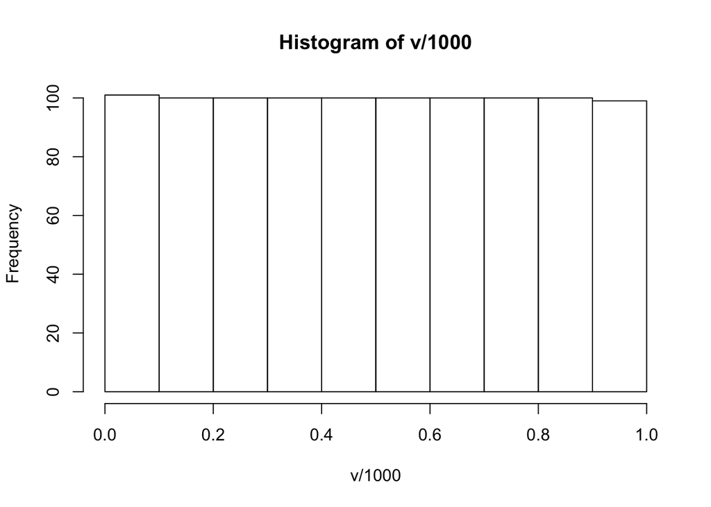

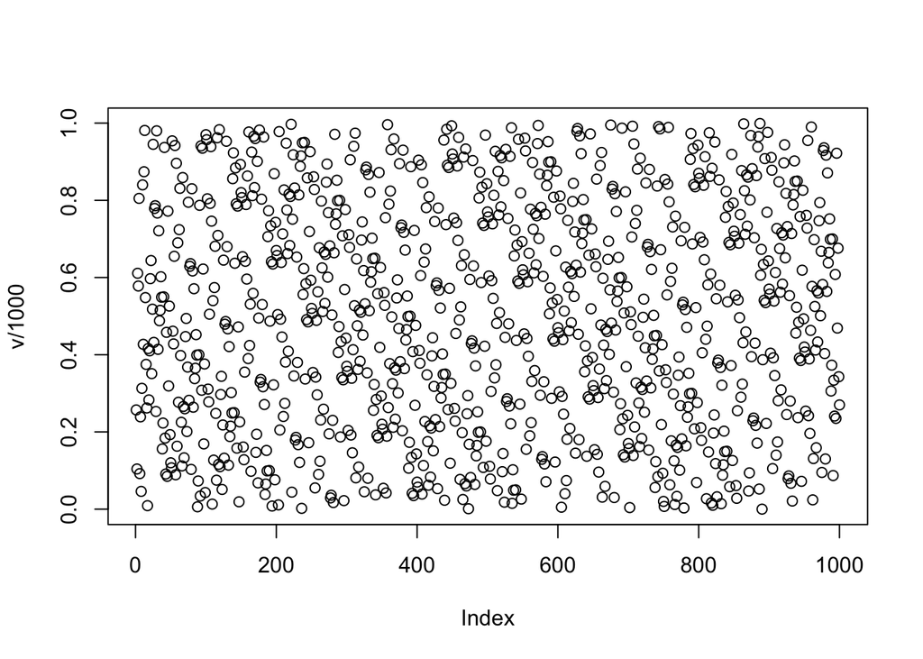

- b 小題要用 acf , pacf 來看是不是來自標準常態分配的亂數，把原本的亂數去掉 0 後除以 1000 ，用 qnorm 指令轉為來自 N(0,1) 的亂數，做出的 histogram 如第下圖所示，很像一個常態分配，接下來的 acf 與 pacf 圖可以看到有超出藍色的虛線，代表他可能不是來自常態的分配，而且這組亂數並不是一個好的亂數。

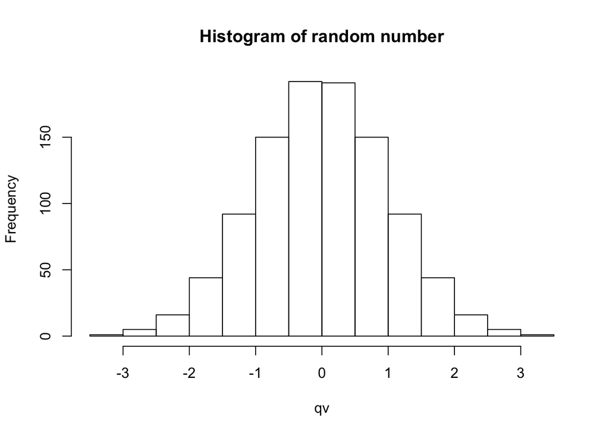

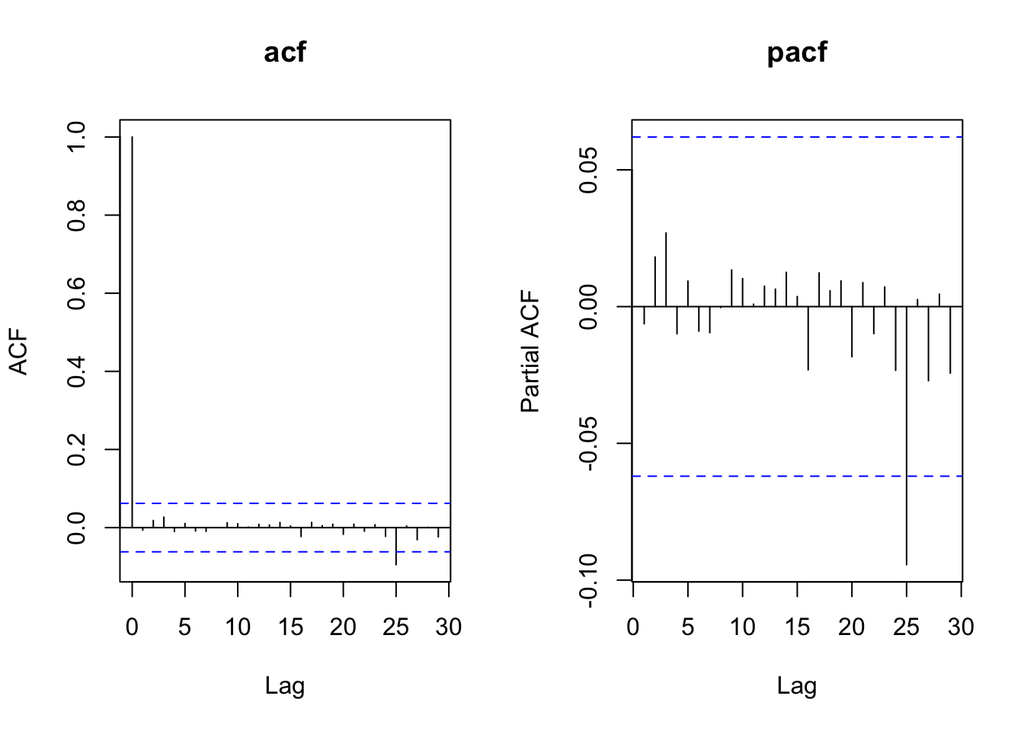

## 第三題

There are several ways for checking the goodness-of-fit for empirical data. In specific, there are a lot of normality tests available in R. Generate a random sample of size 10, 50, and 100 from N(0,1) and t-distribution (with degrees 10 and 20) in R. You may treat testing random numbers from t-distribution as the power. For a level of significance = 0.05 test, choose at least four normality tests in R (“nortest” module) to check if this sample is from N(0,1). Tests used can include the Kolmogorov-Smirnov test and the Cramer-von Mises test. Note that you need to compare the differences among the tests you choose.

- 首先生成樣本數量為 10,50,100 的分佈(4種分佈)~nrom(0,1) 和 t 分佈(自由度分別為 1,10,20 )，為了看到更大的差異值所以增加自由度為 1 的 t 分佈，對上述的樣本選定 4 種檢定 normal 的方法，其中令 pvalue<0.05 的為 1 ，反之為 0 ，重複以上的做法重複 1000 次，計算 1000 次中拒絕 H0 的次數，即拒絕是 normal 分佈的次數

由結果可以看出：

1. df=10,20 的 t 分佈檢定結果很接近 normal，並且隨著 df 的增加越接近
2. 對於 df=1 的 t 分佈來說被拒絕的次數很高，並且隨著樣本的增加拒絕次數增加
3. ks.test 的檢定力相比其他 3 種比較弱

```r
y1 <- function(x){ifelse (ks.test(x,"pnorm")$p.value<0.05,1,0)}
y2 <- function(x){ifelse(cvm.test(x)$p.value< 0.05 ,1,0)}
y3 <- function(x){ifelse(lillie.test(x)$p.value< 0.05 ,1,0)}
y4 <- function(x){ifelse(ad.test(x)$p.value< 0.05 ,1,0)}
A = NULL;B = NULL;C = NULL
for (i in 1:1000){
  t1 = matrix(c(rnorm(10),rt(10,df = 1),rt(10,df = 10),rt(10,df = 20)),nrow=4,byrow=T)
  t2 = matrix(c(rnorm(50),rt(50,df = 1),rt(50,df = 10),rt(50,df = 20)),nrow=4,byrow=T)
  t3 = matrix(c(rnorm(100),rt(100,df = 1),rt(100,df = 10),rt(100,df = 20)),nrow=4,byrow=T)
  a <- matrix(c(apply(t1,1,y1),apply(t1,1,y2),apply(t1,1,y3),apply(t1,1,y4)),ncol=16,byrow=T)
  b <- matrix(c(apply(t2,1,y1),apply(t2,1,y2),apply(t2,1,y3),apply(t2,1,y4)),ncol=16,byrow=T)
  c <- matrix(c(apply(t3,1,y1),apply(t3,1,y2),apply(t3,1,y3),apply(t3,1,y4)),ncol=16,byrow=T)
  A <- rbind(A,a)
  B <- rbind(B,b)
  C <- rbind(C,c)
}
rowN = c("ks.test", "cvm.test","lillie.test","ad.test")
colN = c("nor","t.df=1","t.df=10","t.df=20")
A = matrix(apply(A,2,sum),nrow=4,byrow=T,dimnames = list(rowN,colN))
B = matrix(apply(B,2,sum),nrow=4,byrow=T,dimnames = list(rowN,colN))
C = matrix(apply(C,2,sum),nrow=4,byrow=T,dimnames = list(rowN,colN))
```

```
## [1] "n=10"
```

```
##             nor t.df=1 t.df=10 t.df=20
## ks.test      53    134      57      52
## cvm.test     46    591      78      55
## lillie.test  44    553      68      50
## ad.test      50    594      80      63
```

```
## [1] "n=50"
```

```
##             nor t.df=1 t.df=10 t.df=20
## ks.test      46    480      45      42
## cvm.test     45    998     111      59
## lillie.test  48    994      94      61
## ad.test      51    998     135      70
```

```
## [1] "n=100"
```

```
##             nor t.df=1 t.df=10 t.df=20
## ks.test      49    856      43      46
## cvm.test     53   1000     142      70
## lillie.test  56   1000     121      64
## ad.test      52   1000     165      88
```

## 第四題

```r
# Gap test
gap.test <- function(x, a, b, k){
  x1 <- which(x > a & x < b) #落在指定區間內的位置
  x2 <- x1[-1] - x1[-length(x1)]-1 # 落在指定區間內的數彼此間隔幾個位置
  x3 <- as.data.frame(table(x2))
  t <- c(x3[1:k-1,2], sum(x3[k:dim(x3)[1],2]))
  p=NULL
  m=b-a
  for(i in 1: (k-1) ){
    c <- m*(1-m)^(i-1)
    p <- c(p,c)
  }
  p <- c(p , 1-sum(p) )
  o <- sum(t)*p
  p.value <- 1-pchisq(sum((t-o)^2/o), df=k-1)
  return(p.value)
}

# Permutation test
per.test <- function(x, n){
x1 <- matrix(x, ncol = length(x)/n, byrow = F)
x2 <- apply(x1, 2, rank)
x3 <- 0
a <-  (length(x)/n)/factorial(n)
  f <- function(x){
    k <- 0
      for (i in 1:n) {
        a <- 10^(n-i)*x[i]
        k <- k + a
      }
    return(k)
  }
x3 <- apply(x2, 2, f)
a1 <- table(x3)
p.value <- 1-pchisq(sum((a1-a)^2/a), df=a-1)
return(p.value)
}

K <- matrix(ncol = 2, nrow = 3)
colnames(K) <- c("Excel", "R")
row.names(K) <- c("gap.test", "per.test(n=4)", "per.test(n=3)")

## Excel & R random number compare
rn <- read.csv("rn.csv", sep = ",", header = T)
r <- matrix(runif(1200*50) , ncol = 50)
K[1,1] <- sum( apply(rn, 2, function(x) gap.test(x, a=0.2, b=0.4, k=7)) <0.05 )
K[1,2] <- sum( apply(r, 2, function(x) gap.test(x, a=0.2, b=0.4, k=7)) <0.05 )
K[2,1] <- sum( apply(rn, 2, function(x) per.test(x, n=4)) < 0.05 )
K[2,2] <- sum( apply(r, 2, function(x) per.test(x, n=4)) < 0.05 )
K[3,1] <- sum( apply(rn, 2, function(x) per.test(x, n=3)) < 0.05 )
K[3,2] <- sum( apply(r, 2, function(x) per.test(x, n=3)) < 0.05 )
K
```

```
##               Excel  R
## gap.test          3  0
## per.test(n=4)    36 28
## per.test(n=3)     0  0
```

```r
# Up and down test
run.test <- function(x){
  n <- length(x)
  y <- (x[-1] > x[-n]) *1
  a <- sum(y[-1] != y[-length(y)] )+ 1 # run個數
  mu=(2*n-1)/3
  std=sqrt((16*n-29)/90)
  return(pnorm(a,mean=mu,sd=std))
}

r <- matrix(runif(1000*100) , ncol = 100)
sum( apply(r, 2, run.test) < 0.05)
```

```
## [1] 5
```

## 第五題

$\sum_{i=1}^{12} U_i-6$ can be used to approximate N(0,1) distribution, where $U_i's$ are random sample from U(0,1).

```r
A <- matrix(ncol = 1000, nrow = 2)
row.names(A) <- c("ks.test", "chi.test")
p <- c( pnorm(-2),pnorm(-1)-pnorm(-2),pnorm(0)-pnorm(-1),pnorm(1)-pnorm(0),
        pnorm(2)-pnorm(1), 1-pnorm(2) )
a <- p*1000

for (i in 1:1000) {
  y <- matrix(runif(12000), ncol = 1000)
  y0 <- apply(y, 2, sum)-6
  A[1,i] <- ks.test(y0, "pnorm")$p.value
  o <- c( sum(y0 < -2),sum (y0 > -2 & y0 < -1 ),sum (y0 > -1 & y0 < 0 ),
       sum (y0 > 0 & y0 < 1 ),sum (y0 > 1 & y0 < 2 ),sum (y0 > 2) )
  A[2,i] <- pchisq(sum((a-o)^2/o), df=5)
}
```

```
##          alpha=0.01 alpha=0.05
## ks.test           8         43
## chi.test         10         45
```

- 要用不同的獨立性檢定
- 方法ㄧ：第四題做的 permutation test ，因為這個方法不需要將亂數經過轉換就可以直接做獨立性的檢定，若得出來的 p.value 很小，就會拒絕亂數之間獨立的假設，反之，則為不拒絕亂數之間獨立。
- 方法二：acf , pacf 來看有沒有週期性的變化，不超過兩個藍色虛線就表示他們是獨立的。
- 方法三：用 cox.stuart.test ，若 p.value $> \alpha=0.05$ ，則不拒絕亂數互相獨立的假設。

```r
# Method1:permutation test
y <- matrix(runif(12*1200), ncol = 1200) #ncol代表有幾個隨機變數
x <- apply(y, 2, sum)-6 #U1~U12相加減6 -> normal
per.test(x, 3)
```

```
## [1] 1
```

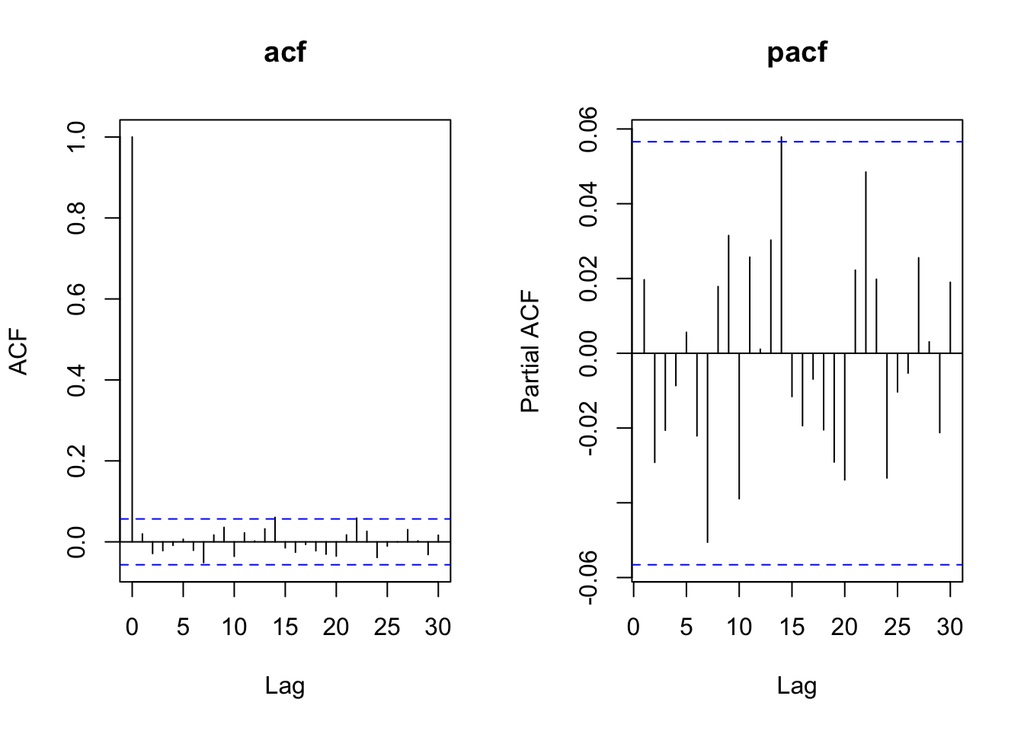

```r
# Method2: pacf acf
par(mfrow=c(1,2))
acf(x, main="acf")
pacf(x, main="pacf")
```

```r
# Method3: cox.stuart.test
library(randtests)
cox.stuart.test(x,"two.sided")$p.value
```

```
## [1] 0.4876998
```